# Risk Factor Analysis

## Outcome Variable

**Outcome Variable:** haz

## Predictor Variables

**Intervention Variable:** cleanck

**Adjustment Set:**

unadjusted

## Stratifying Variables

The analysis was stratified on these variable(s):

- agecat
- studyid
- country

## Data Summary

| agecat | studyid | country | cleanck | n_cell | n |
| --- | --- | --- | --- | --- | --- |
| Birth | ki0047075b-MAL-ED | PERU | 1 | 1 | 2 |
| Birth | ki0047075b-MAL-ED | PERU | 0 | 1 | 2 |
| Birth | ki0047075b-MAL-ED | SOUTH AFRICA | 1 | 1 | 2 |
| Birth | ki0047075b-MAL-ED | SOUTH AFRICA | 0 | 1 | 2 |
| Birth | ki1000108-CMC-V-BCS-2002 | INDIA | 1 | 38 | 90 |
| Birth | ki1000108-CMC-V-BCS-2002 | INDIA | 0 | 52 | 90 |
| Birth | ki1000108-IRC | INDIA | 1 | 218 | 378 |
| Birth | ki1000108-IRC | INDIA | 0 | 160 | 378 |
| Birth | ki1017093c-NIH-Crypto | BANGLADESH | 1 | 12 | 20 |
| Birth | ki1017093c-NIH-Crypto | BANGLADESH | 0 | 8 | 20 |
| 6 months | ki0047075b-MAL-ED | SOUTH AFRICA | 1 | 1 | 1 |
| 6 months | ki0047075b-MAL-ED | SOUTH AFRICA | 0 | 0 | 1 |
| 6 months | ki1000108-CMC-V-BCS-2002 | INDIA | 1 | 163 | 369 |
| 6 months | ki1000108-CMC-V-BCS-2002 | INDIA | 0 | 206 | 369 |
| 6 months | ki1000108-IRC | INDIA | 1 | 230 | 398 |
| 6 months | ki1000108-IRC | INDIA | 0 | 168 | 398 |
| 6 months | ki1017093b-PROVIDE | BANGLADESH | 1 | 482 | 583 |
| 6 months | ki1017093b-PROVIDE | BANGLADESH | 0 | 101 | 583 |
| 6 months | ki1017093c-NIH-Crypto | BANGLADESH | 1 | 329 | 545 |
| 6 months | ki1017093c-NIH-Crypto | BANGLADESH | 0 | 216 | 545 |
| 6 months | ki1113344-GMS-Nepal | NEPAL | 1 | 8 | 504 |
| 6 months | ki1113344-GMS-Nepal | NEPAL | 0 | 496 | 504 |
| 24 months | ki0047075b-MAL-ED | SOUTH AFRICA | 1 | 1 | 1 |
| 24 months | ki0047075b-MAL-ED | SOUTH AFRICA | 0 | 0 | 1 |
| 24 months | ki1000108-CMC-V-BCS-2002 | INDIA | 1 | 163 | 372 |
| 24 months | ki1000108-CMC-V-BCS-2002 | INDIA | 0 | 209 | 372 |
| 24 months | ki1000108-IRC | INDIA | 1 | 231 | 400 |
| 24 months | ki1000108-IRC | INDIA | 0 | 169 | 400 |
| 24 months | ki1017093b-PROVIDE | BANGLADESH | 1 | 479 | 577 |
| 24 months | ki1017093b-PROVIDE | BANGLADESH | 0 | 98 | 577 |
| 24 months | ki1017093c-NIH-Crypto | BANGLADESH | 1 | 199 | 410 |
| 24 months | ki1017093c-NIH-Crypto | BANGLADESH | 0 | 211 | 410 |
| 24 months | ki1113344-GMS-Nepal | NEPAL | 1 | 7 | 446 |
| 24 months | ki1113344-GMS-Nepal | NEPAL | 0 | 439 | 446 |

The following strata were considered:

- agecat: 24 months, studyid: ki0047075b-MAL-ED, country: SOUTH AFRICA
- agecat: 24 months, studyid: ki1000108-CMC-V-BCS-2002, country: INDIA
- agecat: 24 months, studyid: ki1000108-IRC, country: INDIA
- agecat: 24 months, studyid: ki1017093b-PROVIDE, country: BANGLADESH
- agecat: 24 months, studyid: ki1017093c-NIH-Crypto, country: BANGLADESH
- agecat: 24 months, studyid: ki1113344-GMS-Nepal, country: NEPAL
- agecat: 6 months, studyid: ki0047075b-MAL-ED, country: SOUTH AFRICA
- agecat: 6 months, studyid: ki1000108-CMC-V-BCS-2002, country: INDIA
- agecat: 6 months, studyid: ki1000108-IRC, country: INDIA
- agecat: 6 months, studyid: ki1017093b-PROVIDE, country: BANGLADESH
- agecat: 6 months, studyid: ki1017093c-NIH-Crypto, country: BANGLADESH
- agecat: 6 months, studyid: ki1113344-GMS-Nepal, country: NEPAL
- agecat: Birth, studyid: ki0047075b-MAL-ED, country: PERU
- agecat: Birth, studyid: ki0047075b-MAL-ED, country: SOUTH AFRICA
- agecat: Birth, studyid: ki1000108-CMC-V-BCS-2002, country: INDIA
- agecat: Birth, studyid: ki1000108-IRC, country: INDIA
- agecat: Birth, studyid: ki1017093c-NIH-Crypto, country: BANGLADESH

### Dropped Strata

Some strata were dropped due to rare outcomes:

- agecat: Birth, studyid: ki0047075b-MAL-ED, country: PERU
- agecat: Birth, studyid: ki0047075b-MAL-ED, country: SOUTH AFRICA
- agecat: 6 months, studyid: ki0047075b-MAL-ED, country: SOUTH AFRICA
- agecat: 24 months, studyid: ki0047075b-MAL-ED, country: SOUTH AFRICA

## Methods Detail

We’re interested in the causal parameters $E[Y_a]$ for all values of $a \in \mathcal{A}$. These parameters represent the mean outcome if, possibly contrary to fact, we intervened to set all units to have $A=a$. Under the randomization and positivity assumptions, these are identified by the statistical parameters $\psi_a=E_W[E_{Y|A,W}(Y|A=a,W)]$. In addition, we’re interested in the mean of $Y$, $E[Y]$ under no intervention (the observed mean). We will estimate these parameters by using SuperLearner to fit the relevant likelihood factors – $E_{Y|A,W}(Y|A=a,W)$ and $p(A=a|W)$, and then updating our likelihood fit using a joint TMLE.

For unadjusted analyses ($W=\{\}$), initial likelihoods were estimated using Lrnr_glm to estimate the simple $E(Y|A)$ and Lrnr_mean to estimate $p(A)$. For adjusted analyses, a small library containing Lrnr_glmnet, Lrnr_xgboost, and Lrnr_mean was used.

Having estimated these parameters, we will then use the delta method to estimate relative risks and attributable risks relative to a prespecified baseline level of $A$.

# Results Detail

## Results Plots

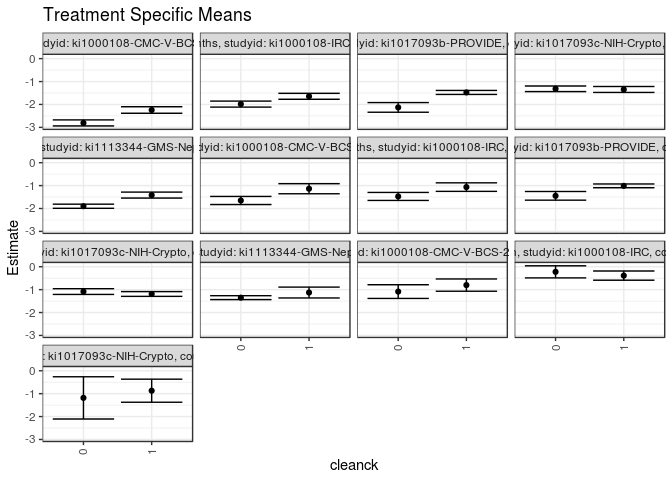

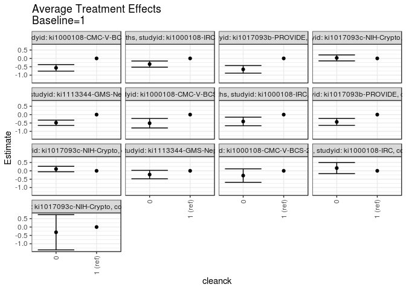

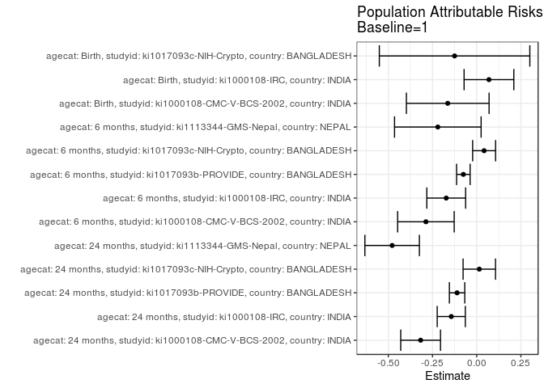

## Results Table

### Parameter: TSM

| agecat | studyid | country | intervention_level | baseline_level | estimate | ci_lower | ci_upper |
| --- | --- | --- | --- | --- | --- | --- | --- |
| Birth | ki1000108-CMC-V-BCS-2002 | INDIA | 1 | NA | -0.8015789 | -1.0692150 | -0.5339429 |
| Birth | ki1000108-CMC-V-BCS-2002 | INDIA | 0 | NA | -1.0851923 | -1.3848062 | -0.7855784 |
| Birth | ki1000108-IRC | INDIA | 1 | NA | -0.3869725 | -0.5877836 | -0.1861613 |
| Birth | ki1000108-IRC | INDIA | 0 | NA | -0.2231875 | -0.4873693 | 0.0409943 |
| Birth | ki1017093c-NIH-Crypto | BANGLADESH | 1 | NA | -0.8708333 | -1.3741980 | -0.3674687 |
| Birth | ki1017093c-NIH-Crypto | BANGLADESH | 0 | NA | -1.1837500 | -2.1056553 | -0.2618447 |
| 6 months | ki1000108-CMC-V-BCS-2002 | INDIA | 1 | NA | -1.1361759 | -1.3567318 | -0.9156199 |
| 6 months | ki1000108-CMC-V-BCS-2002 | INDIA | 0 | NA | -1.6507605 | -1.8276213 | -1.4738997 |
| 6 months | ki1000108-IRC | INDIA | 1 | NA | -1.0650072 | -1.2513917 | -0.8786228 |
| 6 months | ki1000108-IRC | INDIA | 0 | NA | -1.4733829 | -1.6483482 | -1.2984176 |
| 6 months | ki1017093b-PROVIDE | BANGLADESH | 1 | NA | -1.0115906 | -1.0935299 | -0.9296513 |
| 6 months | ki1017093b-PROVIDE | BANGLADESH | 0 | NA | -1.4474752 | -1.6367939 | -1.2581566 |
| 6 months | ki1017093c-NIH-Crypto | BANGLADESH | 1 | NA | -1.1902432 | -1.2949870 | -1.0854993 |
| 6 months | ki1017093c-NIH-Crypto | BANGLADESH | 0 | NA | -1.0842593 | -1.2096802 | -0.9588383 |
| 6 months | ki1113344-GMS-Nepal | NEPAL | 1 | NA | -1.1268750 | -1.3633603 | -0.8903897 |
| 6 months | ki1113344-GMS-Nepal | NEPAL | 0 | NA | -1.3503763 | -1.4349591 | -1.2657936 |
| 24 months | ki1000108-CMC-V-BCS-2002 | INDIA | 1 | NA | -2.2420859 | -2.3845379 | -2.0996338 |
| 24 months | ki1000108-CMC-V-BCS-2002 | INDIA | 0 | NA | -2.8068182 | -2.9380784 | -2.6755580 |
| 24 months | ki1000108-IRC | INDIA | 1 | NA | -1.6442496 | -1.7740028 | -1.5144965 |
| 24 months | ki1000108-IRC | INDIA | 0 | NA | -1.9848028 | -2.1154081 | -1.8541974 |
| 24 months | ki1017093b-PROVIDE | BANGLADESH | 1 | NA | -1.4750939 | -1.5623908 | -1.3877971 |
| 24 months | ki1017093b-PROVIDE | BANGLADESH | 0 | NA | -2.1287755 | -2.3391492 | -1.9184018 |
| 24 months | ki1017093c-NIH-Crypto | BANGLADESH | 1 | NA | -1.3451256 | -1.4744152 | -1.2158361 |
| 24 months | ki1017093c-NIH-Crypto | BANGLADESH | 0 | NA | -1.3165403 | -1.4391902 | -1.1938903 |
| 24 months | ki1113344-GMS-Nepal | NEPAL | 1 | NA | -1.4150000 | -1.5449685 | -1.2850315 |
| 24 months | ki1113344-GMS-Nepal | NEPAL | 0 | NA | -1.9011314 | -1.9910305 | -1.8112322 |

### Parameter: E(Y)

| agecat | studyid | country | intervention_level | baseline_level | estimate | ci_lower | ci_upper |
| --- | --- | --- | --- | --- | --- | --- | --- |
| Birth | ki1000108-CMC-V-BCS-2002 | INDIA | NA | NA | -0.9654444 | -1.1742112 | -0.7566777 |
| Birth | ki1000108-IRC | INDIA | NA | NA | -0.3176455 | -0.4788394 | -0.1564516 |
| Birth | ki1017093c-NIH-Crypto | BANGLADESH | NA | NA | -0.9960000 | -1.4776141 | -0.5143859 |
| 6 months | ki1000108-CMC-V-BCS-2002 | INDIA | NA | NA | -1.4234508 | -1.5645974 | -1.2823042 |
| 6 months | ki1000108-IRC | INDIA | NA | NA | -1.2373869 | -1.3694835 | -1.1052903 |
| 6 months | ki1017093b-PROVIDE | BANGLADESH | NA | NA | -1.0871041 | -1.1635539 | -1.0106543 |
| 6 months | ki1017093c-NIH-Crypto | BANGLADESH | NA | NA | -1.1482385 | -1.2287866 | -1.0676904 |
| 6 months | ki1113344-GMS-Nepal | NEPAL | NA | NA | -1.3468287 | -1.4295445 | -1.2641129 |
| 24 months | ki1000108-CMC-V-BCS-2002 | INDIA | NA | NA | -2.5593683 | -2.6601027 | -2.4586339 |
| 24 months | ki1000108-IRC | INDIA | NA | NA | -1.7881333 | -1.8826438 | -1.6936229 |
| 24 months | ki1017093b-PROVIDE | BANGLADESH | NA | NA | -1.5861179 | -1.6693668 | -1.5028689 |
| 24 months | ki1017093c-NIH-Crypto | BANGLADESH | NA | NA | -1.3304146 | -1.4194311 | -1.2413981 |
| 24 months | ki1113344-GMS-Nepal | NEPAL | NA | NA | -1.8935015 | -1.9813928 | -1.8056102 |

### Parameter: ATE

| agecat | studyid | country | intervention_level | baseline_level | estimate | ci_lower | ci_upper |
| --- | --- | --- | --- | --- | --- | --- | --- |
| Birth | ki1000108-CMC-V-BCS-2002 | INDIA | 1 | 1 | 0.0000000 | 0.0000000 | 0.0000000 |
| Birth | ki1000108-CMC-V-BCS-2002 | INDIA | 0 | 1 | -0.2836134 | -0.6853565 | 0.1181298 |
| Birth | ki1000108-IRC | INDIA | 1 | 1 | 0.0000000 | 0.0000000 | 0.0000000 |
| Birth | ki1000108-IRC | INDIA | 0 | 1 | 0.1637850 | -0.1680541 | 0.4956240 |
| Birth | ki1017093c-NIH-Crypto | BANGLADESH | 1 | 1 | 0.0000000 | 0.0000000 | 0.0000000 |
| Birth | ki1017093c-NIH-Crypto | BANGLADESH | 0 | 1 | -0.3129167 | -1.3632906 | 0.7374572 |
| 6 months | ki1000108-CMC-V-BCS-2002 | INDIA | 1 | 1 | 0.0000000 | 0.0000000 | 0.0000000 |
| 6 months | ki1000108-CMC-V-BCS-2002 | INDIA | 0 | 1 | -0.5145846 | -0.7972942 | -0.2318751 |
| 6 months | ki1000108-IRC | INDIA | 1 | 1 | 0.0000000 | 0.0000000 | 0.0000000 |
| 6 months | ki1000108-IRC | INDIA | 0 | 1 | -0.4083757 | -0.6640161 | -0.1527353 |
| 6 months | ki1017093b-PROVIDE | BANGLADESH | 1 | 1 | 0.0000000 | 0.0000000 | 0.0000000 |
| 6 months | ki1017093b-PROVIDE | BANGLADESH | 0 | 1 | -0.4358847 | -0.6421748 | -0.2295945 |
| 6 months | ki1017093c-NIH-Crypto | BANGLADESH | 1 | 1 | 0.0000000 | 0.0000000 | 0.0000000 |
| 6 months | ki1017093c-NIH-Crypto | BANGLADESH | 0 | 1 | 0.1059839 | -0.0574226 | 0.2693904 |
| 6 months | ki1113344-GMS-Nepal | NEPAL | 1 | 1 | 0.0000000 | 0.0000000 | 0.0000000 |
| 6 months | ki1113344-GMS-Nepal | NEPAL | 0 | 1 | -0.2235013 | -0.4746577 | 0.0276550 |
| 24 months | ki1000108-CMC-V-BCS-2002 | INDIA | 1 | 1 | 0.0000000 | 0.0000000 | 0.0000000 |
| 24 months | ki1000108-CMC-V-BCS-2002 | INDIA | 0 | 1 | -0.5647323 | -0.7584378 | -0.3710268 |
| 24 months | ki1000108-IRC | INDIA | 1 | 1 | 0.0000000 | 0.0000000 | 0.0000000 |
| 24 months | ki1000108-IRC | INDIA | 0 | 1 | -0.3405531 | -0.5246554 | -0.1564509 |
| 24 months | ki1017093b-PROVIDE | BANGLADESH | 1 | 1 | 0.0000000 | 0.0000000 | 0.0000000 |
| 24 months | ki1017093b-PROVIDE | BANGLADESH | 0 | 1 | -0.6536816 | -0.8814487 | -0.4259145 |
| 24 months | ki1017093c-NIH-Crypto | BANGLADESH | 1 | 1 | 0.0000000 | 0.0000000 | 0.0000000 |
| 24 months | ki1017093c-NIH-Crypto | BANGLADESH | 0 | 1 | 0.0285853 | -0.1496246 | 0.2067953 |
| 24 months | ki1113344-GMS-Nepal | NEPAL | 1 | 1 | 0.0000000 | 0.0000000 | 0.0000000 |
| 24 months | ki1113344-GMS-Nepal | NEPAL | 0 | 1 | -0.4861314 | -0.6441619 | -0.3281008 |

### Parameter: PAR

| agecat | studyid | country | intervention_level | baseline_level | estimate | ci_lower | ci_upper |
| --- | --- | --- | --- | --- | --- | --- | --- |
| Birth | ki1000108-CMC-V-BCS-2002 | INDIA | 1 | NA | -0.1638655 | -0.3978011 | 0.0700701 |
| Birth | ki1000108-IRC | INDIA | 1 | NA | 0.0693270 | -0.0713713 | 0.2100253 |
| Birth | ki1017093c-NIH-Crypto | BANGLADESH | 1 | NA | -0.1251667 | -0.5509330 | 0.3005996 |
| 6 months | ki1000108-CMC-V-BCS-2002 | INDIA | 1 | NA | -0.2872749 | -0.4472468 | -0.1273030 |
| 6 months | ki1000108-IRC | INDIA | 1 | NA | -0.1723797 | -0.2820970 | -0.0626624 |
| 6 months | ki1017093b-PROVIDE | BANGLADESH | 1 | NA | -0.0755135 | -0.1136819 | -0.0373451 |
| 6 months | ki1017093c-NIH-Crypto | BANGLADESH | 1 | NA | 0.0420046 | -0.0229047 | 0.1069139 |
| 6 months | ki1113344-GMS-Nepal | NEPAL | 1 | NA | -0.2199537 | -0.4648433 | 0.0249359 |
| 24 months | ki1000108-CMC-V-BCS-2002 | INDIA | 1 | NA | -0.3172824 | -0.4297845 | -0.2047803 |
| 24 months | ki1000108-IRC | INDIA | 1 | NA | -0.1438837 | -0.2233989 | -0.0643685 |
| 24 months | ki1017093b-PROVIDE | BANGLADESH | 1 | NA | -0.1110239 | -0.1545937 | -0.0674541 |
| 24 months | ki1017093c-NIH-Crypto | BANGLADESH | 1 | NA | 0.0147110 | -0.0770124 | 0.1064344 |
| 24 months | ki1113344-GMS-Nepal | NEPAL | 1 | NA | -0.4785015 | -0.6326836 | -0.3243194 |